# evapoRe

Akbar Rahmati Ziveh, Mijael Rodrigo Vargas Godoy, Vishal Thakur, Yannis Markonis

2025-04-10

The `evapoRe` package developed as a complementary toolbox to the pRecipe package (Vargas Godoy and Markonis 2023), available at [https://CRAN.R-project.org/package=pRecipe]. `evapoRe` facilitates the download, exploration, visualization, and analysis of evapotranspiration (ET) data. Additionally, evapoRe offers the functionality to calculate various Potential EvapoTranspiration (PET) methods.

## Before We Start

Like many other R packages, `evapoRe` has some system requirements:

- [PROJ](https://proj.org/download.html)
- Geospatial Data Abstraction Library [(GDAL)](https://gdal.org/en/stable/download.html)
- Network Common Data Form [(NetCDF)](https://www.unidata.ucar.edu/software/netcdf/)

## Data

`evapoRe` database hosts 13 different ET data sets; three satellite-based, five reanalysis, and five hydrological model products. Their native specifications, as well as links to their providers, and their respective references are detailed in the following subsections. We have already homogenized, compacted to a single file, and stored them in a [Zenodo repository](https://doi.org/10.5281/zenodo.10011192) under the following naming convention:

`<data set>_<variable>_<units>_<coverage>_<start date>_<end date>_<resolution>_<time step>.nc`

The `evapoRe` data collection was homogenized to these specifications:

- `<variable>` = evapotranspiration (e)
- `<units>` = millimeters (mm)
- `<resolution>` = 0.25°

E.g., ERA5 (Hersbach et al. 2020) would be:

`era5_e_mm_global_195901_202112_025_monthly.nc`

### Satellite-Based Products

| Data Set | Spatial Resolution | Spatial Coverage Global | Spatial Coverage Land | Spatial Coverage Ocean | Temporal Resolution | Record Length | Get Data | Reference |
| --- | --- | --- | --- | --- | --- | --- | --- | --- |
| GLEAM V3.7b | 0.25° |  | x |  | Monthly | 1980/01-2021/12 | [Download](https://www.gleam.eu/) | Martens et al. (2017) |
| BESS V2.0 | 0.05° |  | x |  | Monthly | 1982/01-2019/12 | [Download](https://www.environment.snu.ac.kr/bessv2) | B. Li et al. (2023) |
| ETMonitor | 1$km$ |  | x |  | Daily | 2000/06-2019/12 | [Download](https://data.casearth.cn/en/sdo/detail/63291c7e08415d54af833fe5) | Zheng et al. (2022) |

### Reanalysis Products

| Data Set | Spatial Resolution | Spatial Coverage Global | Spatial Coverage Land | Spatial Coverage Ocean | Temporal Resolution | Record Length | Get Data | Reference |
| --- | --- | --- | --- | --- | --- | --- | --- | --- |
| ERA5-Land | 0.1° |  | x |  | Monthly | 1960/01-2022/12 | [Download](https://cds.climate.copernicus.eu/datasets/reanalysis-era5-land-monthly-means?tab=overview) | Muñoz-Sabater et al. (2021) |
| ERA5 | 0.25° |  | x |  | Monthly | 1959/01-2021/12 | [Download](https://cds.climate.copernicus.eu/datasets/reanalysis-era5-single-levels-monthly-means?tab=overview) | Hersbach et al. (2020) |
| JRA-55 | 1.25° |  | x |  | Monthly | 1958/01-2021/12 | [Download](https://rda.ucar.edu/datasets/ds628.1/dataaccess/) | Kobayashi et al. (2015) |
| MERRA-2 | 0.5° x 0.625° |  | x |  | Monthly | 1980/01-2023/01 | [Download](https://disc.gsfc.nasa.gov/datasets?page=1&project=MERRA-2) | Gelaro et al. (2017) |
| CAMELE | 0.25° |  | x |  | Monthly | 1980/01-2022/12 | [Download](https://zenodo.org/records/8047038) | C. Li and al. (2023) |

### Hydrological Models

| Data Set | Spatial Resolution | Spatial Coverage Global | Spatial Coverage Land | Spatial Coverage Ocean | Temporal Resolution | Record Length | Get Data | Reference |
| --- | --- | --- | --- | --- | --- | --- | --- | --- |
| FLDAS | 0.1° |  | x |  | Monthly | 1982/01-2022/12 | [Download](https://ldas.gsfc.nasa.gov/fldas/fldas-data-download) | McNally et al. (2017) |
| GLDAS CLSM V2.1 | 1° |  | x |  | Monthly | 2000/01-2022/11 | [Download](https://ldas.gsfc.nasa.gov/gldas/gldas-get-data) | Rodell et al. (2004) |
| GLDAS NOAH V2.1 | 0.25° |  | x |  | Monthly | 2000/01-2022/11 | [Download](https://ldas.gsfc.nasa.gov/gldas/gldas-get-data) | Rodell et al. (2004) and Beaudoing and Rodell (2020) |
| GLDAS VIC V2.1 | 1° |  | x |  | Monthly | 2000/01-2022/11 | [Download](https://ldas.gsfc.nasa.gov/gldas/gldas-get-data) | Rodell et al. (2004) |
| TerraClimate | 4$km$ |  | x |  | Monthly | 1958/01-2021/12 | [Download](https://www.climatologylab.org/terraclimate.html) | Abatzoglou et al. (2018) |

# Demo

In this introductory demo we will first download the GLDAS-CLSM data set. We will then subset the downloaded data over Mediterranean region for the 2001-2010 period, and crop it to the national scale for Spain. In paralel, we will estimate potential evapotranspiration over the same domain and the same record length. In the next step, we will generate time series for our data sets and conclude with the visualization of our data.

## Installation

```r
devtools::install_github("AkbarR1184/evapoRe") #latest dev version
install.packages('evapoRe')                    #latest CRAN release
library(evapoRe)
```

## Download

Downloading the entire data collection or only a few data sets is quite straightforward. You just call the `download_data` function, which has four arguments *data_name*, *path*, *domain*, and *time_res*.

- *data_name* is set to “all” by default, but you can specify the names of your data sets of interest only.
- *path* can be set to “.”. I.e., the current working directory. By replacing it for [your_project_folder], the downloaded files will be stored in [your_project_folder] instead.
- *domain* is set to “raw” by default, but you can specify the domain of your interest only. E.g., “ocean” for ocean only data sets (For availability please check the Data section).
- *time_res* is set to “monthly” by default, but if you prefer you can also download annual data with “yearly”.

Let’s download the GLDAS CLSM data set and inspect its content with `infoNC`:

```r
download_data(data_name = 'gldas-clsm', path = ".")
gldas_clsm_global <- raster::brick('gldas-clsm_e_mm_land_200001_202211_025_monthly.nc')
infoNC(gldas_clsm_global)
```

```
[1] "class      : RasterBrick "
[2] "dimensions : 720, 1440, 1036800, 275  (nrow, ncol, ncell, nlayers)"
[3] "resolution : 0.25, 0.25  (x, y)"
[4] "extent     : -180, 180, -90, 90  (xmin, xmax, ymin, ymax)"
[5] "crs        : +proj=longlat +datum=WGS84 "
[6] "source     : gldas-clsm_e_mm_land_200001_202211_025_monthly.nc "
[7] "names      : X2000.01.01, X2000.02.01, X2000.03.01, X2000.04.01, X2000.05.01, X2000.06.01, X2000.07.01, X2000.08.01, X2000.09.01, X2000.10.01, X2000.11.01, X2000.12.01, X2001.01.01, X2001.02.01, X2001.03.01, ... "
[8] "Date       : 2000-01-01, 2022-11-01 (min, max)"
[9] "varname    : e "
```

## Processing

Once we have downloaded our database, we can start processing the data with:

- `crop_data` to crop the data using a shapefile.
- `fldmean` to generate a time series by taking the area weighted average over each timestep.
- `remap` to go from the native resolution (0.25°) to coarser ones (e.g., 0.5°, 1°, 1.5°, …).
- `subset_data` to subset the data in time and/or space.
- `yearstat` to aggregate the data from monthly into annual.

### Subset

To subset our data to a desired region and period of interest, we use the `subset_data` function, which has three arguments *x*, *box*, and *yrs*.

- *x* Raster* object or a data.table or a filename (character).
- *box* is the bounding box of the region of interest with the coordinates in degrees in the form (xmin, xmax, ymin, ymax).
- *yrs* is the period of interest with years in the form (start_year, end_year).

Let’s subset the GLDAS CLSM data set over Mediterranean region (-10,40,30,45) for the 2001-2010 period, and inspect its content with `infoNC`:

```r
gldas_clsm_subset <- subset_data(gldas_clsm_global,box = c(-10,40,30,45) ,yrs = c(2001, 2010))
infoNC(gldas_clsm_subset)
```

```
[1] "class      : RasterBrick "
[2] "dimensions : 60, 200, 12000, 120  (nrow, ncol, ncell, nlayers)"
[3] "resolution : 0.25, 0.25  (x, y)"
[4] "extent     : -10, 40, 30, 45  (xmin, xmax, ymin, ymax)"
[5] "crs        : +proj=longlat +datum=WGS84 +no_defs "
[6] "source     : memory"
[7] "names      :  X2001.01.01,  X2001.02.01,  X2001.03.01,  X2001.04.01,  X2001.05.01,  X2001.06.01,  X2001.07.01,  X2001.08.01,  X2001.09.01,  X2001.10.01,  X2001.11.01,  X2001.12.01,  X2002.01.01,  X2002.02.01,  X2002.03.01, ... "
[8] "min values :  0.85979986,  1.62062681,  1.42477119,  0.76781327,  0.75662607,  0.34450921,  0.25072542,  0.15768366,  0.13057871,  0.05979802,  0.11780920, -0.69875073,  0.36552662,  0.70131457,  0.63548779, ... "
[9] "max values :    80.61240,    89.56071,   101.81876,   143.45859,   158.37830,   202.83186,   192.55907,   190.07066,   111.40405,   116.93645,    67.32398,    48.42713,    74.23843,    59.85103,    88.96181, ... "
[10] "time       : 2001-01-01, 2010-12-01 (min, max)"
```

### Crop

To further crop our data to a desired polygon other than a rectangle, we use the `crop_data` function, which has two arguments *x*, and *y*.

- *x* Raster* object or a data.table or a *.nc filename (character).
- *y* is a “.shp” filename (character).

Let’s crop our GLDAS CLSM subset to cover only Spain with the respective [shape file](https://geodata.ucdavis.edu/gadm/gadm4.1/shp/gadm41_ESP_shp.zip), and inspect its content with `infoNC`:

```r
gldas_clsm_esp <- crop_data(gldas_clsm_subset, "gadm41_ESP_0.shp")
infoNC(gldas_clsm_esp)
```

```
[1] "class      : RasterBrick "
[2] "dimensions : 56, 58, 3248, 120  (nrow, ncol, ncell, nlayers)"
[3] "resolution : 0.25, 0.25  (x, y)"
[4] "extent     : -10, 4.5, 30, 44  (xmin, xmax, ymin, ymax)"
[5] "crs        : +proj=longlat +datum=WGS84 +no_defs "
[6] "source     : memory"
[7] "names      : X2001.01.01, X2001.02.01, X2001.03.01, X2001.04.01, X2001.05.01, X2001.06.01, X2001.07.01, X2001.08.01, X2001.09.01, X2001.10.01, X2001.11.01, X2001.12.01, X2002.01.01, X2002.02.01, X2002.03.01, ... "
[8] "min values :   7.216680,   18.606867,   32.398956,   37.939827,   39.484840,   29.796391,   15.073787,   17.676109,   15.789503,   26.564753,   13.147447,    9.846310,    8.794820,   14.355796,   26.288857, ... "
[9] "max values :    80.61240,    89.56071,   101.81876,   139.86717,   151.03282,   197.47284,   146.44232,   145.36212,   111.40405,   116.93645,    67.32398,    48.42713,    74.23843,    58.79382,    88.13857, ... "
[10] "time       : 2001-01-01, 2010-12-01 (min, max)"
```

### PET calculation

First we need to download temperature data, available at: [Zenodo repository](https://doi.org/10.5281/zenodo.10019933):

**NOTE:** Temperature data available at the moment is limited to monthly. The data sets are TerraClimate, MSWX, and CRU and for brevity We will only estimate PET over the 2001 to 2010 period using MSWX dataset.

we use the `download_t_data` function, which has five arguments *data_name*, *variable*, *path*, *time_res*, and *domain*.

- *data_name* is the dataset name you can specify the names of your data sets of interest.
- *variable* is the variable name in which `t2m`,`tmin`, and `tmax` stand for average temperature, minimum temperature, and maximum temperature.
- *path* can be set to “.”. I.e., the current working directory. By replacing it for [your_project_folder], the downloaded files will be stored in [your_project_folder] instead.
- *domain* is set to “raw” by default, but you can specify the domain of your interest only. E.g., “ocean” for ocean only data sets (For availability please check the Data section).
- *time_res* is set to “monthly” by default, but if you prefer you can also download annual data with “yearly”.

```r
download_t_data(data_name ="mswx", variable = "t2m", path = ".")
```

This will download temperature data in following naming convention e.g.,

`mswx_t2m_degC_land_197901_202308_025_monthly.nc`

As stated above we will work only with the 2001-2010 period. Since `evapoRe` makes all of `pRecipe` functions available we can load and subset the data as follows:

```r
t2m_global <- raster::brick("mswx_t2m_degC_land_197901_202308_025_monthly.nc") %>%
  subset_data(yrs = c(2001, 2010))
infoNC(t2m_global)
```

```
[1] "class      : RasterBrick "
[2] "dimensions : 720, 1440, 1036800, 120  (nrow, ncol, ncell, nlayers)"
[3] "resolution : 0.25, 0.25  (x, y)"
[4] "extent     : -180, 180, -90, 90  (xmin, xmax, ymin, ymax)"
[5] "crs        : +proj=longlat +datum=WGS84 +no_defs "
[6] "source     : memory"
[7] "names      : X2001.01.01, X2001.02.01, X2001.03.01, X2001.04.01, X2001.05.01, X2001.06.01, X2001.07.01, X2001.08.01, X2001.09.01, X2001.10.01, X2001.11.01, X2001.12.01, X2002.01.01, X2002.02.01, X2002.03.01, ... "
[8] "min values :  -49.867680,  -45.244373,  -42.529930,  -33.551258,  -22.829224,  -15.122508,  -13.402536,  -14.673846,  -18.428692,  -27.443539,  -35.674980,  -44.693199,  -46.778694,  -47.197075,  -42.277370, ... "
[9] "max values :    35.00875,    33.52000,    33.29000,    35.04688,    38.26308,    39.35505,    40.33314,    39.98806,    36.99562,    33.00374,    32.52186,    33.59248,    34.46944,    33.25062,    33.71313, ... "
[10] "time       : 2001-01-01, 2010-12-01 (min, max)"
```

The `pet` function estimates PET using a method of choice from the following available options:

- *bc* for Blaney and Criddle (Blaney 1952).
- *ha* for Hamon (Hamon 1961)
- *jh* for Jensen and Haise (Jensen and Haise 1963)
- *mb* for McGuinness and Bordne (McGuinness and Bordne 1972)
- *od* for Oudin (Oudin et al. 2005)
- *th* for Thornthwaite (Thornthwaite 1948)

The `pet` function has two arguments *x* and *method*.

- *x* is a RasterBrick object with average temperature data.
- *method* a character string indicating the method to be used.

Let’s calculate PET using the Oudin formulation. Then, same as GLDAS CLSM we can subset it over Mediterranean region and Spain, and inspect its content with `infoNC`:

**NOTE:** `pet` output is [mm/day], in order to get values in [mm] for a 1 to 1 comparison we use `muldpm` function.

```r
pet_oudin_global <- pet(t2m_global, method = "od") %>% muldpm
infoNC(pet_oudin_global)
```

```
[1] "class      : RasterBrick "
[2] "dimensions : 720, 1440, 1036800, 120  (nrow, ncol, ncell, nlayers)"
[3] "resolution : 0.25, 0.25  (x, y)"
[4] "extent     : -180, 180, -90, 90  (xmin, xmax, ymin, ymax)"
[5] "crs        : +proj=longlat +datum=WGS84 +no_defs "
[6] "source     : memory"
[7] "names      :    layer.1,    layer.2,    layer.3,    layer.4,    layer.5,    layer.6,    layer.7,    layer.8,    layer.9,   layer.10,   layer.11,   layer.12,   layer.13,   layer.14,   layer.15, ... "
[8] "min values : 0.000000e+00, 0.000000e+00, 8.728488e-04, 8.322404e-04, 3.890790e-04, 0.000000e+00, 0.000000e+00, 2.140520e-04, 8.102036e-04, 0.000000e+00, 0.000000e+00, 0.000000e+00, 0.000000e+00, 0.000000e+00, 1.431775e-04, ... "
[9] "max values :     219.5310,     176.8754,     184.4747,     189.0052,     222.4694,     224.2932,     233.6676,     220.5922,     187.6766,     182.0405,     189.9230,     206.4958,     214.1489,     176.4865,     184.7495, ... "
[10] "time       : 2001-01-01, 2010-12-01 (min, max)"
```

```r
pet_oudin_subset <- subset_data(pet_oudin_global, box = c(-10,40,30,45))
infoNC(pet_oudin_subset)
```

[output not shown]

```r
pet_oudin_esp <- crop_data(pet_oudin_subset, "gadm41_ESP_0.shp")
infoNC(pet_oudin_esp)
```

```
[1] "class      : RasterBrick "
[2] "dimensions : 56, 58, 3248, 120  (nrow, ncol, ncell, nlayers)"
[3] "resolution : 0.25, 0.25  (x, y)"
[4] "extent     : -10, 4.5, 30, 44  (xmin, xmax, ymin, ymax)"
[5] "crs        : +proj=longlat +datum=WGS84 +no_defs "
[6] "source     : memory"
[7] "names      :      layer.1,      layer.2,      layer.3,      layer.4,      layer.5,      layer.6,      layer.7,      layer.8,      layer.9,     layer.10,     layer.11,     layer.12,     layer.13,     layer.14,     layer.15, ... "
[8] "min values :   3.5873966,   3.6652387,  23.3621691,  26.7197371,  54.5738134,  83.2697010,  93.0016851,  91.4133866,  49.0935838,  34.9640317,   5.8351220,   0.5116812,   4.7784175,   7.1974645,  19.2179436, ... "
[9] "max values :    40.66180,    48.18053,    80.11776,   100.17784,   125.64010,   160.57205,   165.80086,   155.79110,   111.13910,    80.95558,    44.86891,    37.12437,    40.82948,    48.49249,    74.67580, ... "
[10] "time       : 2001-01-01, 2010-12-01 (min, max)"
```

### Generate Time series

#### Time series for global ET products

To make a time series out of our data, we use the `fldmean` function, which has one argument *x*.

- *x* Raster* object or a data.table or a *.nc filename (character).

Let’s generate the time series for our three different GLDAS CLSM data sets (Global, Mediterranean region, and Spain), and inspect its first 12 rows:

```r
gldas_clsm_global_ts <- fldmean(gldas_clsm_global)
head(gldas_clsm_global_ts, 12)
```

```
      date    value
 1: 2000-01-01 42.63418
 2: 2000-02-01 40.28064
 3: 2000-03-01 46.65724
 4: 2000-04-01 49.73078
 5: 2000-05-01 61.78450
 6: 2000-06-01 71.51643
 7: 2000-07-01 78.34947
 8: 2000-08-01 68.59857
 9: 2000-09-01 52.40877
10: 2000-10-01 45.95624
11: 2000-11-01 40.95821
12: 2000-12-01 41.50710
```

```r
gldas_clsm_subset_ts <- fldmean(gldas_clsm_subset)
head(gldas_clsm_subset_ts, 12)
```

```
     date    value
 1: 2001-01-01 14.47589
 2: 2001-02-01 19.65537
 3: 2001-03-01 38.58488
 4: 2001-04-01 45.47299
 5: 2001-05-01 57.83225
 6: 2001-06-01 63.57403
 7: 2001-07-01 51.30824
 8: 2001-08-01 41.88030
 9: 2001-09-01 29.30722
10: 2001-10-01 24.02233
11: 2001-11-01 16.56476
12: 2001-12-01 12.67189
```

```r
gldas_clsm_esp_ts <- fldmean(gldas_clsm_esp)
head(gldas_clsm_esp_ts, 12)
```

```
        date     value
 1: 2001-01-01  17.99823
 2: 2001-02-01  31.41443
 3: 2001-03-01  57.23334
 4: 2001-04-01  84.13048
 5: 2001-05-01  95.06479
 6: 2001-06-01 118.33516
 7: 2001-07-01  87.58777
 8: 2001-08-01  74.37666
 9: 2001-09-01  45.09689
10: 2001-10-01  43.91893
11: 2001-11-01  25.11206
12: 2001-12-01  16.99089
```

#### Time series for calculated PET

Let’s generate the time series for our three different PET calculated by Oudin method (Global, Mediterranean region, and Spain), and inspect its first 12 rows:

```r
pet_oudin_global_ts <- fldmean(pet_oudin_global)
head(pet_oudin_global_ts, 12)
```

```
        date     value
 1: 2001-01-01  90.97581
 2: 2001-02-01  90.72542
 3: 2001-03-01 100.12134
 4: 2001-04-01  96.08822
 5: 2001-05-01 105.25369
 6: 2001-06-01 110.88759
 7: 2001-07-01 119.98619
 8: 2001-08-01 112.29808
 9: 2001-09-01  94.00018
10: 2001-10-01  89.70338
11: 2001-11-01  82.71571
12: 2001-12-01  90.02744
```

```r
pet_oudin_subset_ts <- fldmean(pet_oudin_subset)
head(pet_oudin_subset_ts, 12)
```

```
         date     value
 1: 2001-01-01  28.41624
 2: 2001-02-01  34.31941
 3: 2001-03-01  70.77386
 4: 2001-04-01  85.68093
 5: 2001-05-01 119.92428
 6: 2001-06-01 146.10311
 7: 2001-07-01 161.36373
 8: 2001-08-01 147.05941
 9: 2001-09-01 105.36592
10: 2001-10-01  73.91439
11: 2001-11-01  37.36657
12: 2001-12-01  24.99642
```

```r
pet_oudin_esp_ts <- fldmean(pet_oudin_esp)
head(pet_oudin_esp_ts, 12)
```

```
         date     value
 1: 2001-01-01  23.33118
 2: 2001-02-01  28.85419
 3: 2001-03-01  57.39954
 4: 2001-04-01  71.95438
 5: 2001-05-01 101.37500
 6: 2001-06-01 134.48663
 7: 2001-07-01 139.09158
 8: 2001-08-01 131.25821
 9: 2001-09-01  87.49866
10: 2001-10-01  59.00385
11: 2001-11-01  25.24541
12: 2001-12-01  16.16446
```

## Visualize

Either after we have processed our data as required or right after downloaded, we have six different options to visualize our data for more information refer to [visualisation section of pRecipe](https://CRAN.R-project.org/package=pRecipe):

### Maps

To see a map of any data set raw or processed, we use `plot_map` which takes only one layer of the RasterBrick as input.

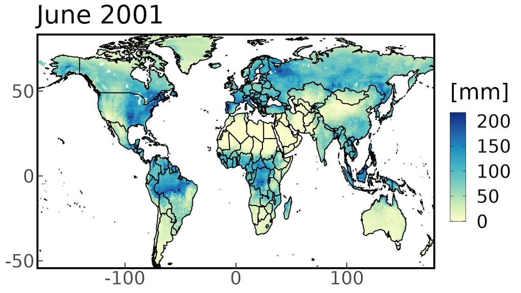

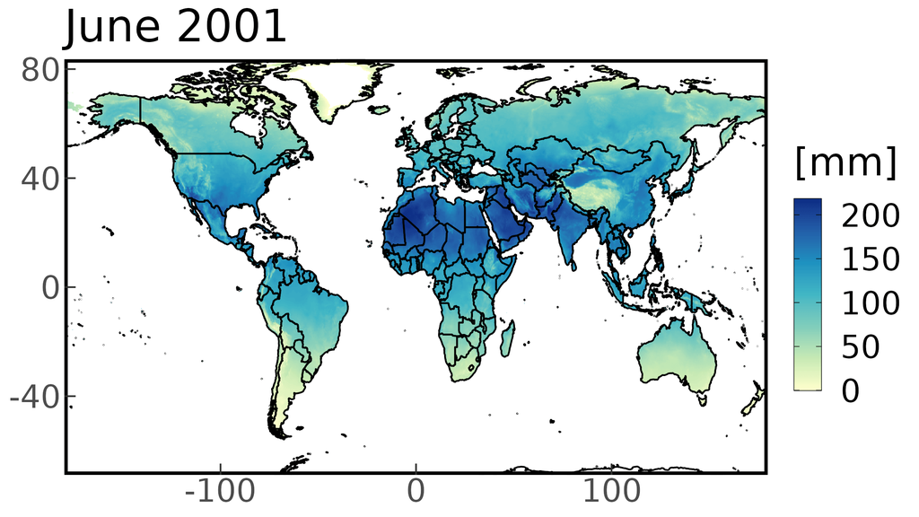

```r
plot_map(gldas_clsm_global[[18]])
plot_map(pet_oudin_global[[6]])
```

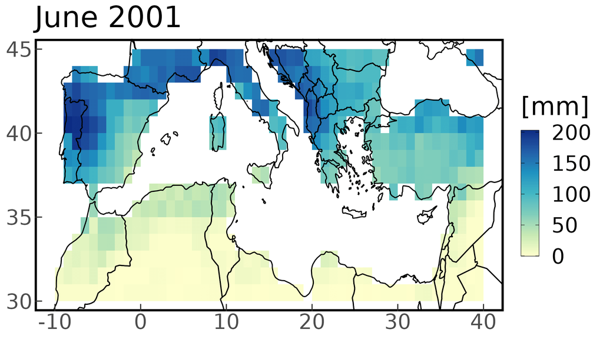

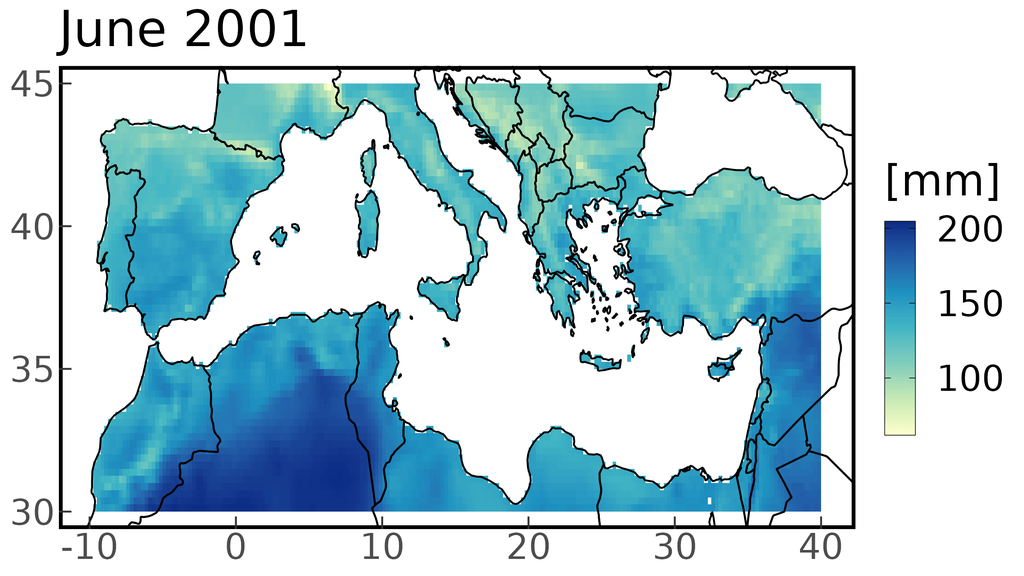

```r
plot_map(gldas_clsm_subset[[6]])
plot_map(pet_oudin_subset[[6]])
```

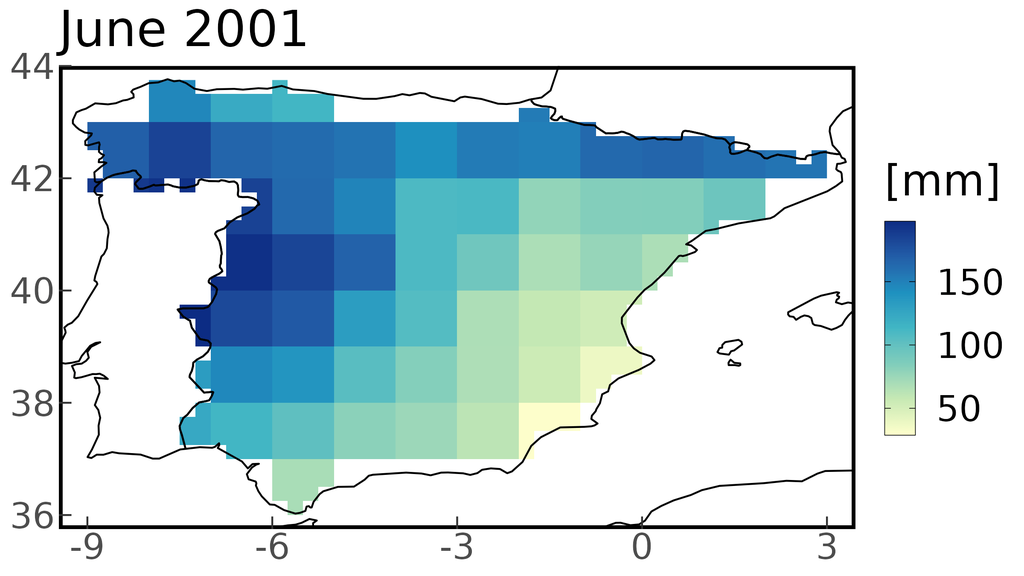

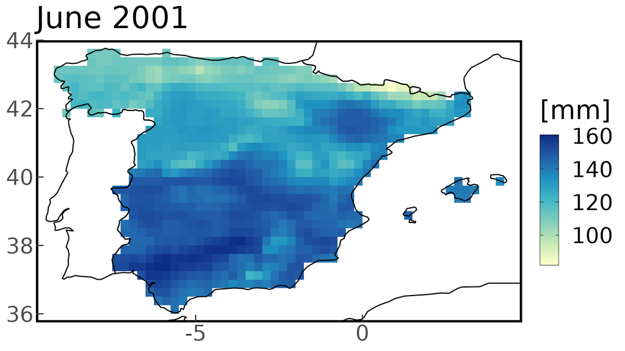

```r
plot_map(gldas_clsm_esp[[6]])
plot_map(pet_oudin_esp[[6]])
```

### Time Series Visuals

To draw a time series generated by `fldmean`, we use any of the options below, which takes only a `fldmean` “.csv” generated file.

#### Lineplots

##### Plotting globals

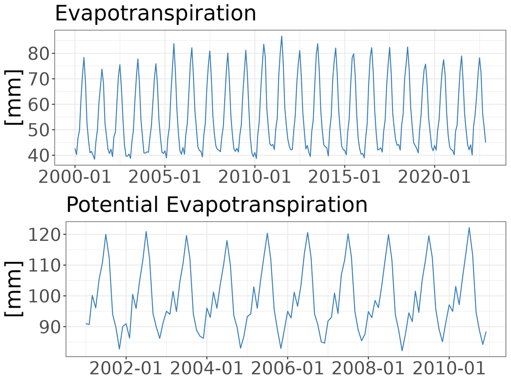

```r
p01 <- plot_line(gldas_clsm_global_ts, var = "Evapotranspiration")
p02 <- plot_line(pet_oudin_global_ts, var = "Potential Evapotranspiration")
ggpubr::ggarrange(p01, p02, ncol = 1)
```

##### Plotting subsets

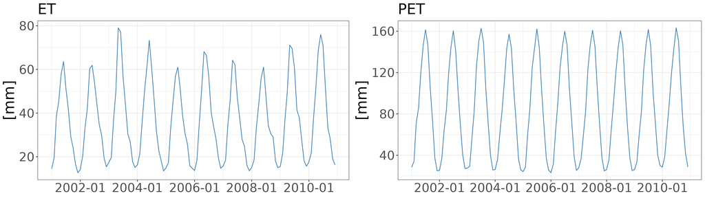

```r
p01 <- plot_line(gldas_clsm_subset_ts, var = "ET")
p02 <- plot_line(pet_oudin_subset_ts, var = "PET")
ggpubr::ggarrange(p01, p02, ncol = 2)
```

##### Plotting Spain

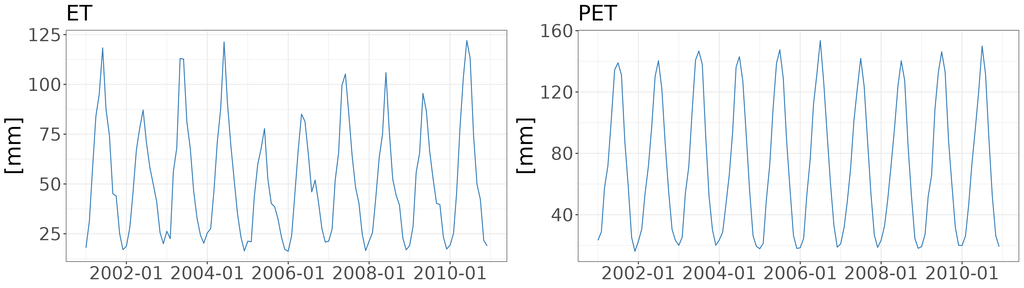

```r
p01 <- plot_line(gldas_clsm_esp_ts, var = "ET")
p02 <- plot_line(pet_oudin_esp_ts, var = "PET")
ggpubr::ggarrange(p01, p02, ncol = 2)
```

#### Heatmap

##### Plotting globals

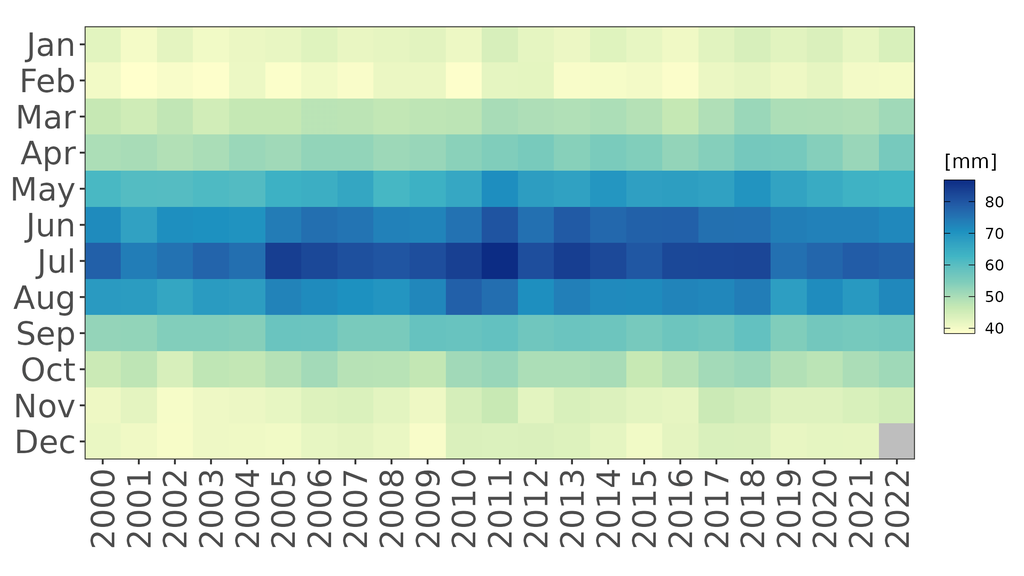

```r
plot_heatmap(gldas_clsm_global_ts)
```

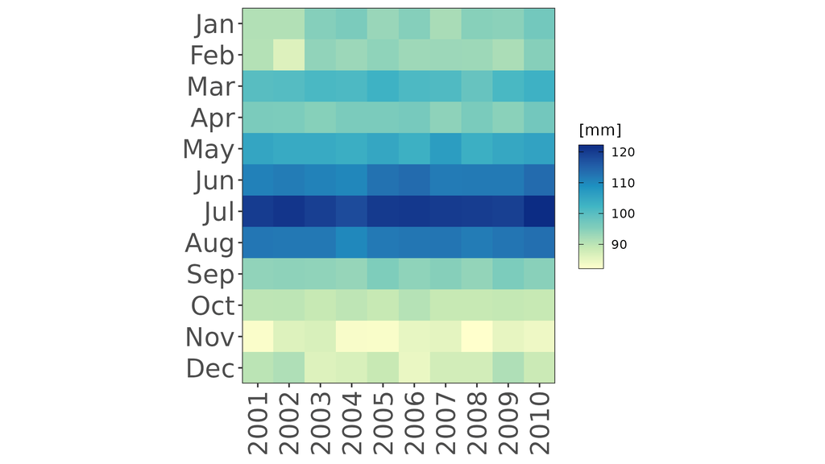

```r
plot_heatmap(pet_oudin_global_ts)
```

##### Plotting subsets

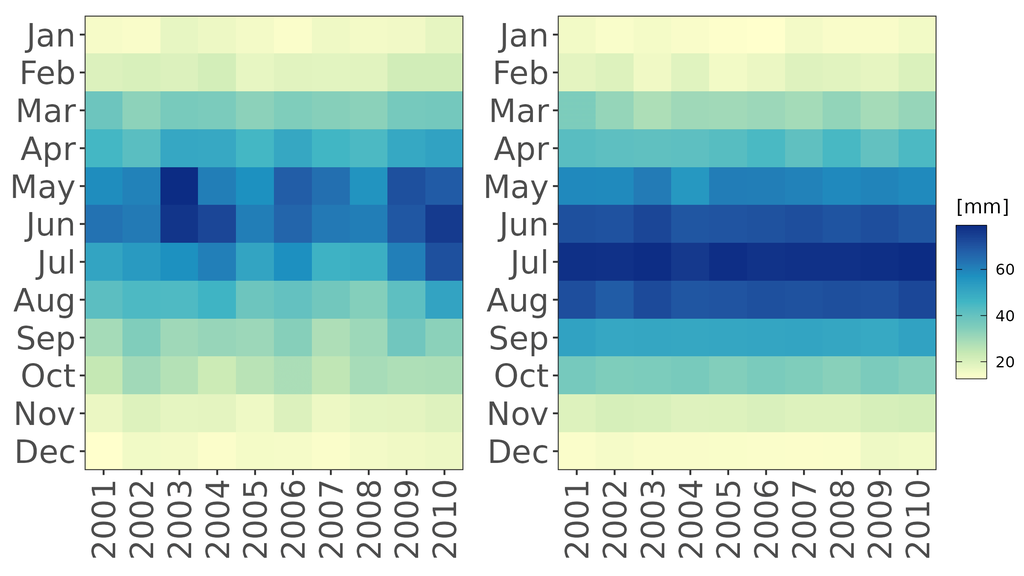

```r
p01 <- plot_heatmap(gldas_clsm_subset_ts)
p02 <- plot_heatmap(pet_oudin_subset_ts)
ggpubr::ggarrange(p01, p02, ncol = 2, common.legend = TRUE, legend = "right")
```

##### Plotting Spain

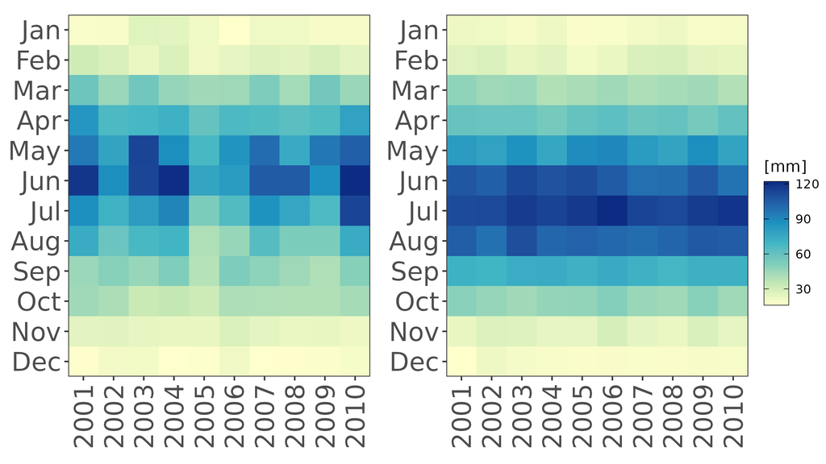

```r
p01 <- plot_heatmap(gldas_clsm_esp_ts)
p02 <- plot_heatmap(pet_oudin_esp_ts)
ggpubr::ggarrange(p01, p02, ncol = 2, common.legend = TRUE, legend = "right")
```

#### Boxplot

##### Plotting globals

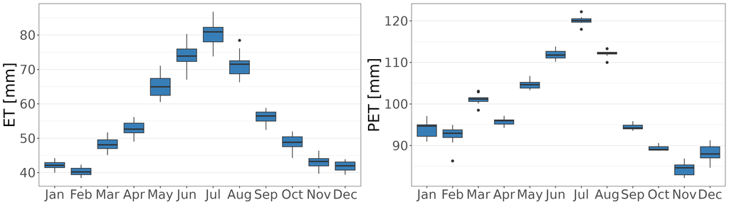

```r
p01 <- plot_box(gldas_clsm_global_ts, var = "ET")
p02 <- plot_box(pet_oudin_global_ts, var = "PET")
ggpubr::ggarrange(p01, p02, ncol = 2)
```

##### Plotting subsets

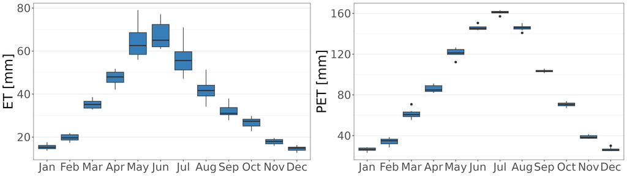

```r
p01 <- plot_box(gldas_clsm_subset_ts, var = "ET")
p02 <- plot_box(pet_oudin_subset_ts, var = "PET")
ggpubr::ggarrange(p01, p02, ncol = 2)
```

##### Plotting Spain

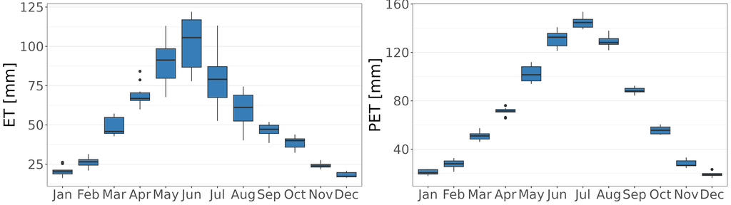

```r
p01 <- plot_box(gldas_clsm_esp_ts, var = "ET" )
p02 <- plot_box(pet_oudin_esp_ts, var = "PET" )
ggpubr::ggarrange(p01, p02, ncol = 2)
```

#### Density plots

##### Plotting globals

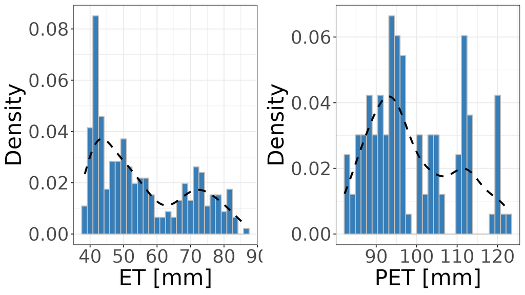

```r
p01 <- plot_density(gldas_clsm_global_ts, var = "ET")
p02 <- plot_density(pet_oudin_global_ts, var = "PET")
ggpubr::ggarrange(p01, p02, ncol = 2)
```

##### Plotting subsets

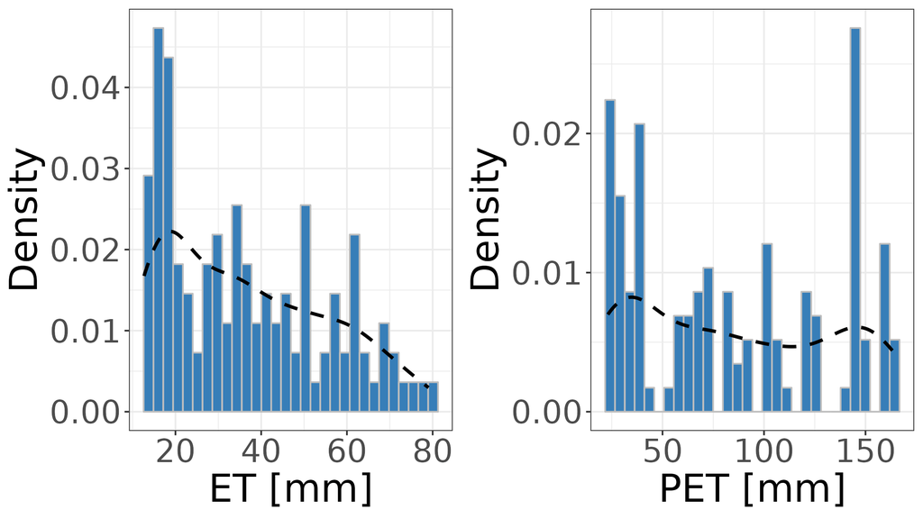

```r
p01 <- plot_density(gldas_clsm_subset_ts, var = "ET")
p02 <- plot_density(pet_oudin_subset_ts, var = "PET")
ggpubr::ggarrange(p01, p02, ncol = 2)
```

##### Plotting Spain

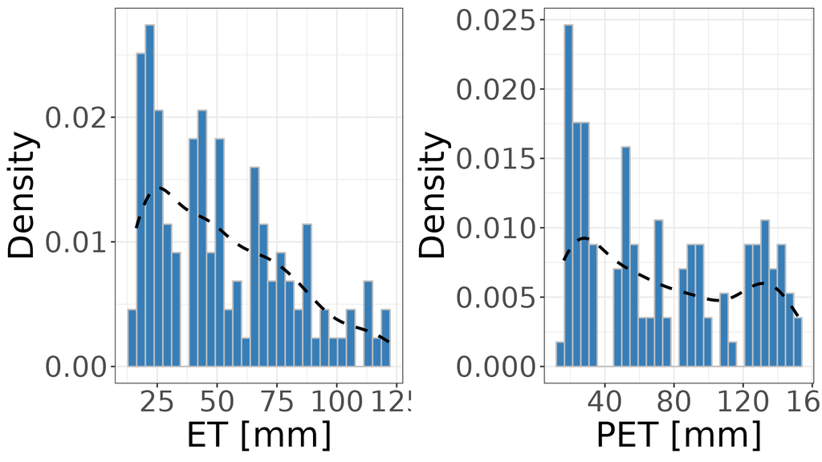

```r
p01 <- plot_density(gldas_clsm_esp_ts, var = "ET")
p02 <- plot_density(pet_oudin_esp_ts, var = "PET")
ggpubr::ggarrange(p01, p02, ncol = 2)
```

#### Summary

**NOTE:** For good aesthetics we recommend saving `plot_summary` with `ggsave(<filename>, <plot>, width = 16.3, height = 15.03)`.

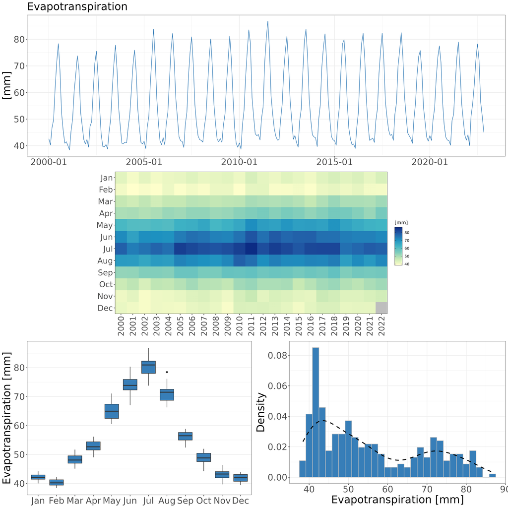

```r
plot_summary(gldas_clsm_global_ts, var = "Evapotranspiration")
#plot_summary(gldas_clsm_subset_ts, var = "Evapotranspiration")
#plot_summary(gldas_clsm_esp_ts, var = "Evapotranspiration")
#plot_summary(pet_oudin_global_ts, var = "Potential Evapotranspiration")
#plot_summary(pet_oudin_subset_ts)
#plot_summary(pet_oudin_esp_ts)
```

# Coming Soon

We will introduce significant enhancements to ET database and PET calculation methods. This expansion builds upon our existing temperature-based approach and incorporates a radiation-based PET calculation methods, along with an expanded range of temperature-based methods. Our aim is to provide users with a more comprehensive and accurate estimation of ET and PET, catering to a broader range of applications and requirements.

# References

Abatzoglou, John T, Solomon Z Dobrowski, Sean A Parks, and Katherine C Hegewisch. 2018. “TerraClimate, a High-Resolution Global Dataset of Monthly Climate and Climatic Water Balance from 1958–2015.” *Scientific Data* 5 (1): 1–12.

Beaudoing, Hiroko, and Matthew Rodell. 2020. “GLDAS Noah Land Surface Model L4 monthly 0.25 x 0.25 degree V2.1.” Greenbelt, Maryland, USA: Goddard Earth Sciences Data and Information Services Center (GES DISC). https://doi.org/10.5067/SXAVCZFAQLNO.

Blaney, Harry French. 1952. “Determining Water Requirements in Irrigated Areas from Climatological and Irrigation Data.”

Gelaro, Ronald, Will McCarty, Max J. Suárez, Ricardo Todling, Andrea Molod, Lawrence Takacs, Cynthia A. Randles, et al. 2017. “The Modern-Era Retrospective Analysis for Research and Applications, Version 2 (MERRA-2).” *Journal of Climate* 30 (14): 5419–54. https://doi.org/10.1175/JCLI-D-16-0758.1.

Hamon, W. R. 1961. “Estimating Potential Evapotranspiration.” *Journal of the Hydraulics Division* 87 (3): 107–20.

Hersbach, Hans, Bill Bell, Paul Berrisford, Shoji Hirahara, András Horányi, Joaquín Muñoz-Sabater, Julien Nicolas, et al. 2020. “The ERA5 Global Reanalysis.” *Quarterly Journal of the Royal Meteorological Society* 146 (730): 1999–2049.

Jensen, M. E., and H. R. Haise. 1963. “Estimating Evapotranspiration from Solar Radiation.” *Journal of the Irrigation and Drainage Division* 89 (4): 15–41.

Kobayashi, Shinya, Yukinari Ota, Yayoi Harada, Ayataka Ebita, Masami Moriya, Hirokatsu Onoda, Kazutoshi Onogi, et al. 2015. “The JRA-55 Reanalysis: General Specifications and Basic Characteristics.” *Journal of the Meteorological Society of Japan. Ser. II* 93 (1): 5–48. https://doi.org/10.2151/jmsj.2015-001.

Li, B., Y. Ryu, C. Jiang, B. Dechant, J. Liu, Y. Yan, and X. Li. 2023. “BESSv2.0: A Satellite-Based and Coupled-Process Model for Quantifying Long-Term Global Land–Atmosphere Fluxes.” *Remote Sensing of Environment* 295: 113696.

Li, Changming, and et al. 2023. “CAMELE: Collocation-Analyzed Multi-Source Ensembled Land Evapotranspiration Data.” *Earth System Science Data Discussions* 2023: 1–60.

Martens, Brecht, Diego G. Miralles, Hans Lievens, Robin van der Schalie, Richard A. M. de Jeu, Diego Fernández-Prieto, Hylke E. Beck, Wouter A. Dorigo, and Niko E. C. Verhoest. 2017. “GLEAM v3: satellite-based land evaporation and root-zone soil moisture.” *Geoscientific Model Development* 10 (5): 1903–25. https://doi.org/10.5194/gmd-10-1903-2017.

McGuinness, J. L., and E. F. Bordne. 1972. “A Comparison of Lysimeter-Derived Potential Evapotranspiration with Computed Values.” 1452. US Department of Agriculture.

McNally, Amy, Kristi Arsenault, Sujay Kumar, Shraddhanand Shukla, Pete Peterson, Shugong Wang, Chris Funk, Christa D. Peters-Lidard, and James P. Verdin. 2017. “A Land Data Assimilation System for Sub-Saharan Africa Food and Water Security Applications.” *Scientific Data* 4 (1): 170012. https://doi.org/10.1038/sdata.2017.12.

Muñoz-Sabater, Joaquín, Gianpaolo Balsamo, Emanuel Dutra, Hans Hersbach, Patricia López, Diego Miralles, Robin van der Schalie, et al. 2021. “ERA5-Land: A state-of-the-art global reanalysis dataset for land applications.” *Earth System Science Data* 13 (9): 4349–83. https://doi.org/10.5194/essd-13-4349-2021.

Oudin, L., F. Hervieu, C. Michel, C. Perrin, V. Andréassian, F. Anctil, and C. Loumagne. 2005. “Which Potential Evapotranspiration Input for a Lumped Rainfall–Runoff Model?: Part 2–Towards a Simple and Efficient Potential Evapotranspiration Model for Rainfall–Runoff Modelling.” *Journal of Hydrology* 303 (1-4): 290–306.

Rodell, Matthew, Paul R. Houser, Uli Jambor, Jon Gottschalck, Ken Mitchell, Chuanmin Meng, Kristi Arsenault, et al. 2004. “The Global Land Data Assimilation System.” *Bulletin of the American Meteorological Society* 85: 381–94. https://doi.org/10.1175/BAMS-85-3-381.

Thornthwaite, C. W. 1948. “An Approach Toward a Rational Classification of Climate.” *Geographical Review* 38 (1): 55–94.

Vargas Godoy, Mijael Rodrigo, and Yannis Markonis. 2023. “pRecipe: A Global Precipitation Climatology Toolbox and Database.” *Environmental Modelling & Software* 165: 105711.

Zheng, C., L. Chaolei, L. Jia, and H. Guangcheng. 2022. “Global Land Surface Evapotranspiration Monitoring by ETMonitor Model Driven by Multi-Source Satellite Earth Observations.” *Journal of Hydrology* 613: 128444.